# Final Project

2022-11-11

# Introduction

As technology and the internet have developed, people from all over the world are now active on social media. As Twitter is a conversational social media platform, any discussion about a current issue in a country will quickly spread all over the world. Twitter feeds frequently include user thoughts about the latest political, social, and economic problems that exist in a certain nation. These tweets reveal a lot about the nation’s political climate and socioeconomic situation. Also, announcements from brands, trending memes, posts from content creators and social media influencers where people react, provide suggestions and feedback count for a decent portion of the engagement on twitter. The responses, feelings, and ideas posted on Twitter—which are also a gauge of sentiment of the users—might be somehow connected to the GDP of the nation. Surveys, polls, and other techniques can be used to gather information about people’s opinions and feelings towards the nation’s economy. As Twitter is overfilled with sentimental tweets because of which it becomes the most accessible platform for sentiment analysis.

The datasets provided to us in the course had the sentiment data for countries across the world for the year 2020 and 2021 along with scores, country name and number of posts generated for each day throughout these years. The given sentiment scores were a measure of average positiveness of the tweet from all the tweets collected from a specific country for the given day. For exploring the relationship between sentiment and other variables like Gross Domestic Product (GDP), Average Working Hours and Internet Users, relevant data was obtained from several databases which will be discussed in the Methods section. In this paper, we use visualization techniques in the R programming language to see the relationship between the sentiment scores and other variables. We will analyze how people respond and express their sentiment with respect to growth GDP mainly as well as other variables.

# Literature Review

Since the years 2020 and 2021 were impacted by the Covid-19 pandemic, it is important to study them in that context. Previous literature shows that people have used social media during this lockdown to share their emotions and find a method to relax themselves as millions of people have been affected by the virus, and several nations have gone into total lockdown.. A study has conducted a sentiment analysis of tweets by nation. Twelve different nations’ tweets were taken into consideration for this study project. These tweets, which link to COVID19 in some form, were collected between March 11 and March 31, 2020. This investigation was conducted to see how people are responding to the situation in various nations. After being gathered and pre-processed, the tweets were utilized for text mining and sentiment analysis. The study’s findings suggest that while most individuals throughout the world choose a cheerful and upbeat attitude, there are still instances of fear, despair, and contempt displayed globally. In contrast to the other eight nations, four—France, Switzerland, the Netherlands, and the United States of America—have displayed signals of mistrust and rage on a more significant scale. In other words, there was shown to be a strong correlation between negative emotions and Covid-19 cases in these countries (Dubey, 2020).

Another study further asserts that there was a definite evolution of online behaviors and sentiments in light of Covid-19 pandemic. In this study, they seek to comprehend the impact of the pandemic on users’ social media interactions, particularly their public perception. They conducted topic modeling across 23 subjects using a huge dataset of 26 million English tweets from four nations and 14 significant cities, as well as a temporal and semantic analysis on a monthly basis. The data demonstrates how the public’s conversation about health care is becoming more and more concerned, moving away from themes like politics and sports and toward internet shopping and the financial impacts of the epidemic on society. What’s more intriguing is that over time, overall user expressiveness has improved as shown by the emotion of their tweets on various subjects (Alshamrani, 2021).

In regards to the relationship between sentiment analysis and economic performance, a paper examines internet data, contrasting how news that was broadcast through the news media directly influenced the index of the New York stock market in comparison to the price of gold and crude oil. In order to determine the potential for more future studies using sentiment analysis on news data in the stock market, the result analysis analyzes interpretation theories involving a behavior development of the stock markets as a result of terrorist acts or epidemics. The study compares the sentiment analysis of news stories on the impact of the key worldwide stock markets’ economic decline to that of earlier terrorist acts or epidemics (9/11, Covid-19). To appropriately integrate the inquiry into the theoretical framework, they first give a summary of the previous research on how terrorism affects financial markets. The practical aspect largely involves determining if the return of the primary index of the New York Stock Market has changed statistically as a result of the attacks in relation to the deviations of the four months prior to and following the attack (Biswas, 2020).

The seeming gap between economic progress and happiness, sometimes known as the “Easterlin Paradox,” is a key paradox of the literature on happiness. Over the past thirty years, real income has increased, but happiness has stagnated or maybe even decreased. There are several reasons for this. Some focus on psychological aspects, such relative deprivation or rising financial unhappiness, while others focus on the behavior linked to increased salaries, including longer work hours and the compromises these hours need for leisure, relationships, and health. This paper proves the complexity of these trends and contends that once we take into account multiple sources of satisfaction, trends in real income have less paradoxical implications. It does this by using a sample of working-age American adults and the cumulative General Social Survey from 1973 to 2004. The article concludes the possibility that falling marital satisfaction and the proportion of Americans in working age who are married have been the main causes of declining happiness. However, these patterns have mostly been unrelated to income trends. In fact, the downward trend in happiness changes once marital considerations are taken into account, and economic reasons become the single most significant factor underpinning increased happiness. This outcome reflects a variety of factors. First, developments in financial happiness have recently coincided with increases in real income, defying predictions of rising financial discontent. In addition, despite rising economic disparity, views of relative income have grown. Finally in relation to happiness levels and average work hours, the authors concluded that there is no proof that families are “overworked,” at least not in terms of satisfaction. Families are undoubtedly working longer hours, and trade-offs between work hours and various sources of wellbeing exist (sometimes sharply). Families are, however, a long way from reaching a position where their happiness is threatened by their work schedules. Families are, if anything, getting closer to their ideal state. Overall, the findings imply that happiness is the sum of a variety of elements, and that much may be achieved by emphasizing economic advancements as well as the reasonable behaviors—both objective and subjective—that underlie these achievements (Schnittker, 2008).

The question asked in another paper is what level of happiness, growth may bring to low-income nations. It analyzes the connection between increasing wealth and subjective well-being. According to the Easterlin paradox, increasing income is usually correlated with better happiness scores, with the exception of one situation in which it is still highly contested whether rising national income results in greater well-being. Whether the correlation coefficient is “too small to matter” is the crucial question. According to some theories, there is only a weak relationship over time between national economic growth and subjective well-being (because of development’s inherent drawbacks, such pollution), and that relationship is further complicated by the psychological significance of relative worries and adaptability. The evidence at hand teaches us two crucial lessons: Even in extremely impoverished nations, income comparisons do appear to have an impact on subjective well-being; nevertheless, adaptation may be more of a rich-country phenomena. According to this a, the author, assumption that growth would raise happiness in low-income nations cannot be disproved on the basis of the data at hand. First, aggregate measures—which are less accurate than those at the individual level—are used in cross-country time-series studies. Second, development is a qualitative process that includes thresholds and take-off points. With the use of subjective satisfaction measurements, such regime changes may be seen. In this regard, the situation of Transition nations is particularly interesting since, during the first 10 years or so of the transition process, until the regime became more stable, changes in average life satisfaction closely followed those in GDP (Clark, 2010).

In a paper studying whether hard labor makes you happier and more content, survey data were used to determine whether working more hours has a net positive or negative impact on measures of self-reported subjective happiness, psychological health, and economic satisfaction. The results showed that in general, working overtime is linked to increased job stress, weariness, and work-family conflict. The higher levels of happiness and mental health satisfaction that are otherwise brought about by its increased revenue seem to be negated when overtime labor is necessary. Mandatory overtime hours are connected to more work-family conflict and dissatisfaction for certain employees, while the converse is true for some others. The most effective policies for enhancing social and economic wellbeing of an individual should concentrate on reducing situations where overtime is both required and detrimental (Golden, 2006).

# Hypothesis

From a general perspective, one might expect the growth in GDP to lead to an increase in positive sentiments since many assume GDP to be the indicator of a country’s economy. Decrease in GDP with time might lead to uncertainty amongst people investing their money in trades. Because the economy of a country is decreasing, it can lead to financial insecurities among the public. Also it could go the other way around, for instance, if the sentiment of people is low for some reason (higher crime rate, then that might affect their performances at work, in handling business which could ultimately lead to decline in GDP). Similarly, higher GDP might encourage people to expand their trade, make profits and establish financial freedom which would lead to positive sentiments. Our hypothesis is that an increase in GDP will result in positive sentiments, but we will investigate whether this hypothesis is correct or incorrect in this paper.

# Methods

There are different methods of analyzing the data in a study. For analyzing the sentiment present on twitter with other factors we are going to use a quantitative method for data collection. Quantitative methods involve dealing with numerical data which has statistical importance. While the other method, the qualitative ones, involves understanding the fundamentals of behavior of data and gaining deeper insights into it. As we are going to use quantitative methods, we will be using the provided sentiment dataset as a source of data for gauging people’s emotions and feelings. Sentiment is an individual’s state of mind that is determined by what the person is going through mentally, as well as their feelings and emotions. The circumstances in which a person finds themselves have a significant impact on their mood. Such circumstances can take both physical and mental forms. A person who has a positive or negative reaction to a specific event expresses their feelings through various mediums, such as their attitude, in several places. The twitter data was collected from the Twitter Sentiment Geographical Index dataset which was done by Sustainable Urbanization Lab at MIT and Center for Geographic Analysis at Harvard collaboratively. The dataset contains average sentiment scores for each country on a daily basis. The specific data frames that we were provided with were CSV(Comma Separated Values) files that had the date for observation, name of the country, states or provinces, number of posts generated on the given date and a score which represented the sentiment of a country for that date as variables of interest. The sentiment score was a floating point number which measured the positivity in the tweets i.e. negative sentiment was represented by sentiment score 0 and positive sentiment was represented by 1. The CSV files that we were provided with had country data for the year 2020, 2021 and municipal data for 2021 which additionally had scores for each state or provinces or cities along with the number of posts generated in each state for a given date. However, for the scope of our paper, we are only going to use the country data with sentiment scores for 2020 and 2021. We will only be analyzing sentiment scores versus another variable for countries in general rather than for each state.

The International Monetary Fund defines Gross Domestic Product as the monetary value of goods, services which are produced within a specific country and bought by the final users in a given year. GDP is often seen as the representative indicator of a country’s economy and the ability of citizens to engage more in investing in businesses and trading. We obtained the data for Gross Domestic Product (GDP) for the year 2020 and 2021 for countries across the world through the World Bank. The CSV file contained data for countries represented by country code along with their GDP from the year 1960 to 2021. The GDP of interest for our group project was for the year 2020 and 2021 to compare them with sentiment scores and perform regression analysis with other variables.

Similarly, we will be taking average working hours of individuals in a country as a confounding variable as we suspect that it might both affect the sentiment of people and GDP of a country. The dataset used to extract average working hours was found from Total Economy Database-Data Central (TED) on The Conference Board website. It contained variables such as Employment rate, Per Capita Income, Population, Total Annual Hours, Labor Productivity and many more along with the growth of such variables over time. https://www.conference-board.org/data/economydatabase/total-economy-database-productivity

The data for the number of internet users was obtained from the International Telecommunication Union. The dataset contained the information about the number of internet users from the year 2000 to 2021. Since we are extracting every variable for the years 2020 and 2021 for the analysis, the same would be done for this dataset as well. https://www.itu.int/en/ITU-D/Statistics/Pages/stat/default.aspx

Data cleaning was performed to remove the unwanted columns and to extract only the desired variables from the dataset like, GDP and Sentiment Score for instance from data frames created above. In our case, the datasets contained non numerical values such as “…”, “NA”, and spaces, missing values which had to be omitted to prevent errors during code compilation. Also we noticed differences in naming styles for countries and acronyms used for particular countries. So data cleaning methods were used to maintain consistency and the main aim of it was to develop a standard approach throughout the data analysis process.

```r
data_2020 <- read.csv("data/sentiment_country_2020.csv")
data_2021 <- read.csv("data/sentiment_country_2021.csv")
```

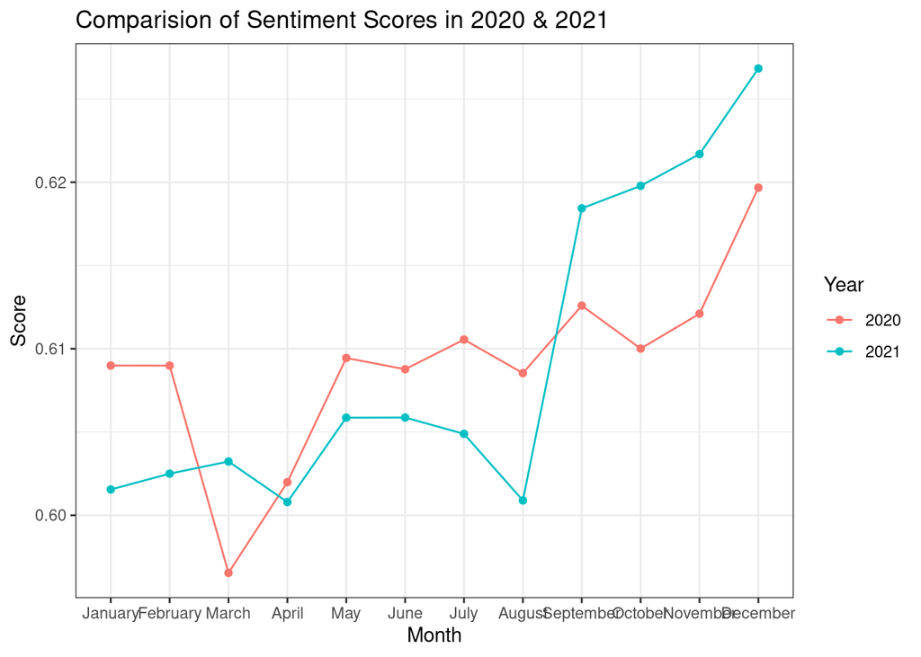

```r
#2020

data_2020$DATE=as.Date(data_2020$DATE)

data_2020$Month <- months(data_2020$DATE)
data_2020$Year <- format(data_2020$DATE,format="%y")

data_2020<-data_2020 %>% filter(!is.na(data_2020$SCORE))

monthly2020=data_2020 %>%
  group_by(Month,Year) %>%
  summarise_at(vars(SCORE),
               list(Score=mean))

monthly2020$Month=factor(monthly2020$Month, levels = month.name)


#2021

data_2021$DATE=as.Date(data_2021$DATE)

data_2021$Month <- months(data_2021$DATE)
data_2021$Year <- format(data_2021$DATE,format="%y")

data_2021<-data_2021 %>% filter(!is.na(data_2021$SCORE))

monthly2021=data_2021 %>%
  group_by(Month,Year) %>%
  summarise_at(vars(SCORE),
               list(Score=mean))

monthly2021$Month=factor(monthly2021$Month, levels = month.name)



monthly <- rbind(monthly2020,monthly2021)


monthly$Year[monthly$Year == "20"] <- "2020"
monthly$Year[monthly$Year == "21"] <- "2021"

ggplot (data=monthly, aes(Month, Score, group = Year, color = Year))+
  geom_point()+geom_line()+
  ggtitle("Comparision of Sentiment Scores in 2020 & 2021")+
  theme_bw()
```

```r
avg_data_2020<-data_2020 %>%
  group_by(NAME_0) %>%
  summarize(
    avg_score_2020 = mean(SCORE, na.rm = TRUE)
    )

avg_data_2021<-data_2021 %>%
  group_by(NAME_0) %>%
  summarize(
    avg_score_2021 = mean(SCORE, na.rm = TRUE)
    )

names(avg_data_2020)[names(avg_data_2020) == "NAME_0"] <- "region"
names(avg_data_2021)[names(avg_data_2021) == "NAME_0"] <- "region"
```

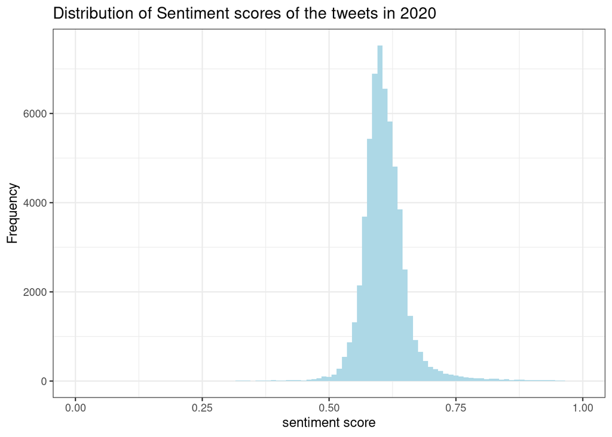

```r
ggplot(data = data_2020, aes(x=SCORE)) +
  geom_histogram(binwidth = 0.01, fill = "lightblue")+
  ylab("Frequency") +
  xlab("sentiment score") +
  ggtitle("Distribution of Sentiment scores of the tweets in 2020")+
  theme_bw()
```

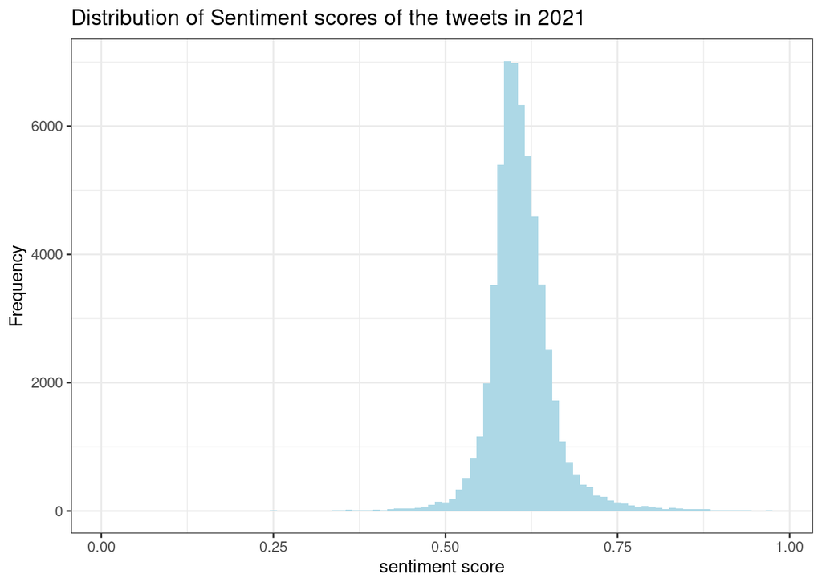

```r
ggplot(data = data_2021, aes(x=SCORE)) +
  geom_histogram(binwidth = 0.01, fill = "lightblue")+
  ylab("Frequency") +
  xlab("sentiment score") +
  ggtitle("Distribution of Sentiment scores of the tweets in 2021")+
  theme_bw()
```

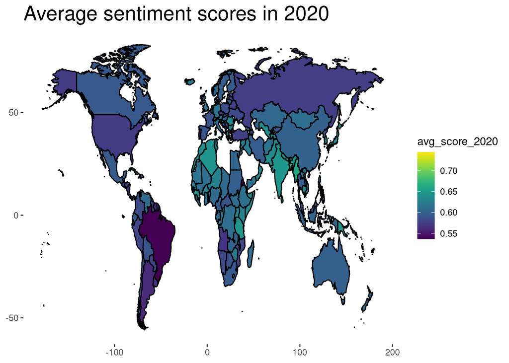

```r
mapdata <- map_data("world")

#changing USA to United States
mapdata$region[mapdata$region == "USA"] <- "United States"

#changing UK to United Kingdom
mapdata$region[mapdata$region == "UK"] <- "United Kingdom"

mapdata <- left_join(mapdata, avg_data_2020, by="region")
mapdata <- left_join(mapdata, avg_data_2021, by="region")

mapdata1<-mapdata %>% filter(!is.na(mapdata$avg_score_2020))
mapdata1<-mapdata %>% filter(!is.na(mapdata$avg_score_2021))


map1<-ggplot(mapdata1, aes( x = long, y = lat, group=group)) +
  geom_polygon(aes(fill = avg_score_2020), color = "black")

map2<-ggplot(mapdata1, aes( x = long, y = lat, group=group)) +
  geom_polygon(aes(fill = avg_score_2021), color = "black")

library(viridis)

map1 <- map1 + scale_fill_gradient(name = "avg score")+
  ggtitle("Average sentiment scores in 2020")+
  theme(plot.title = element_text(size = 20),
        axis.title.y=element_blank(),
        axis.title.x=element_blank(),
        rect = element_blank()) +
scale_fill_viridis()
map1
```

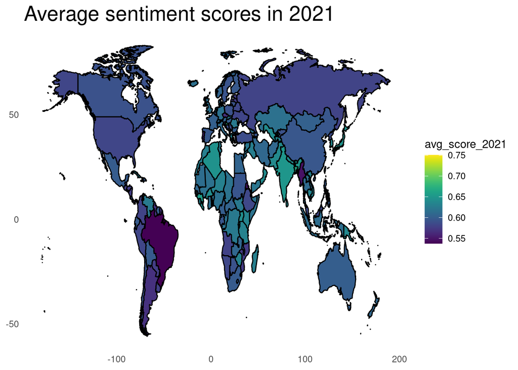

```r
map2 <- map2 + scale_fill_gradient(name = "avg score")+
  ggtitle("Average sentiment scores in 2021")+
  theme( plot.title = element_text(size = 20),
        axis.ticks = element_blank(),
        axis.title.y=element_blank(),
        axis.title.x=element_blank(),
        rect = element_blank())+
scale_fill_viridis()

map2
```

```r
gdp_2020 <- read_csv("gdp_2020.csv")

gdp_2021 <- read_csv("gdp_2021.csv")

gdp_2020 <- gdp_2020[c(1,5)]
gdp_2021 <- gdp_2021[c(1,5)]

names(gdp_2020)[names(gdp_2020) == "Country Name"] <- "region"
names(gdp_2021)[names(gdp_2021) == "Country Name"] <- "region"

names(gdp_2020)[names(gdp_2020) == "2020 [YR2020]"] <- "gdp"
names(gdp_2021)[names(gdp_2021) == "2021 [YR2021]"] <- "gdp"


names(data_2020)[names(data_2020) == "NAME_0"] <- "region"
names(data_2021)[names(data_2021) == "NAME_0"] <- "region"

data_2020 <- left_join(data_2020, gdp_2020, by="region")
data_2021 <- left_join(data_2021, gdp_2021, by="region")

data_total <- rbind(data_2020,data_2021)

sentiment_data <- data_total
```

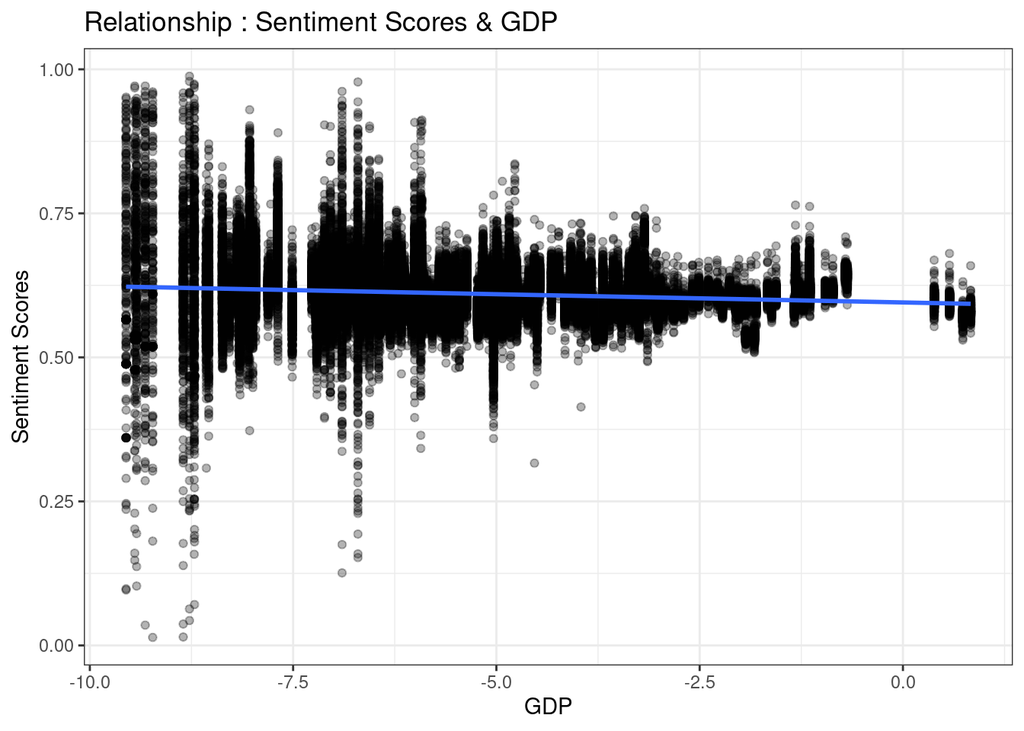

```r
#removing missing values
data_total<-data_total[!(data_total$gdp==".."),]

data_total$gdp <- as.numeric(as.character(data_total$gdp))

data_total$gdp = (data_total$gdp) / 10000000000000

data_total<-data_total %>% filter(!is.na(data_total$gdp))

#taking log of gdp
lgdp=log(data_total$gdp)

ggplot(data = data_total, aes(x = lgdp , y = SCORE))+
  geom_point(alpha = 0.3) +
  geom_smooth(method = "lm")+
  ggtitle("Relationship : Sentiment Scores & GDP")+
  xlab("GDP")+
  ylab("Sentiment Scores")+
  theme_bw()
```

```r
attach(data_total)
m1=lm(SCORE~gdp)
summary(m1)
```

```
##
## Call:
## lm(formula = SCORE ~ gdp)
##
## Residuals:
##      Min       1Q   Median       3Q      Max
## -0.59632 -0.02366 -0.00430  0.02004  0.37777
##
## Coefficients:
##               Estimate Std. Error t value Pr(>|t|)
## (Intercept)  0.6102591  0.0001574 3877.93   <2e-16 ***
## gdp         -0.0107904  0.0006120  -17.63   <2e-16 ***
## ---
## Signif. codes:  0 '***' 0.001 '**' 0.01 '*' 0.05 '.' 0.1 ' ' 1
##
## Residual standard error: 0.04628 on 92131 degrees of freedom
## Multiple R-squared:  0.003362,   Adjusted R-squared:  0.003352
## F-statistic: 310.8 on 1 and 92131 DF,  p-value: < 2.2e-16
```

```r
library(brms)
dv <- brm(formula = SCORE~gdp, data=data_total, family=gaussian , refresh=0)
```

[output not shown]

```r
summary(dv)
```

```
##  Family: gaussian
##   Links: mu = identity; sigma = identity
## Formula: SCORE ~ gdp
##    Data: data_total (Number of observations: 92133)
##   Draws: 4 chains, each with iter = 2000; warmup = 1000; thin = 1;
##          total post-warmup draws = 4000
##
## Population-Level Effects:
##           Estimate Est.Error l-95% CI u-95% CI Rhat Bulk_ESS Tail_ESS
## Intercept     0.61      0.00     0.61     0.61 1.00     5038     2798
## gdp          -0.01      0.00    -0.01    -0.01 1.00     2347     1724
##
## Family Specific Parameters:
##       Estimate Est.Error l-95% CI u-95% CI Rhat Bulk_ESS Tail_ESS
## sigma     0.05      0.00     0.05     0.05 1.00      700      865
##
## Draws were sampled using sampling(NUTS). For each parameter, Bulk_ESS
## and Tail_ESS are effective sample size measures, and Rhat is the potential
## scale reduction factor on split chains (at convergence, Rhat = 1).
```

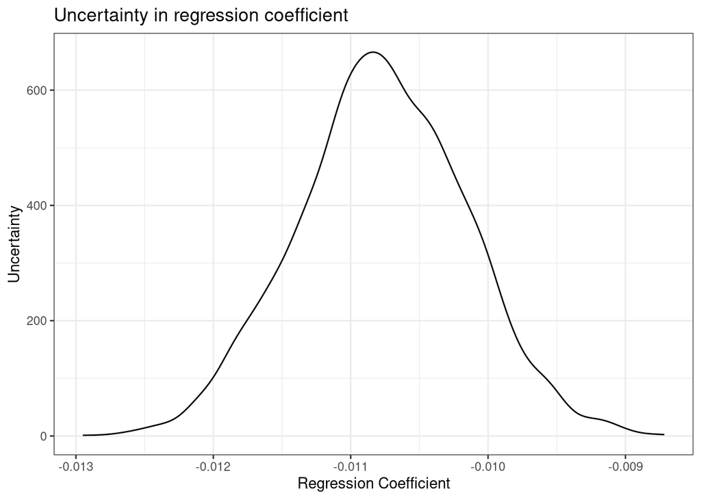

```r
attach(data_total)
uncertainty_coef<-as_draws_df(dv, variable = "b_gdp")
ggplot(uncertainty_coef, aes(x=b_gdp))+
  geom_density()+
  labs(title= "Uncertainty in regression coefficient",x="Regression Coefficient",y="Uncertainty")+
  theme_bw()
```

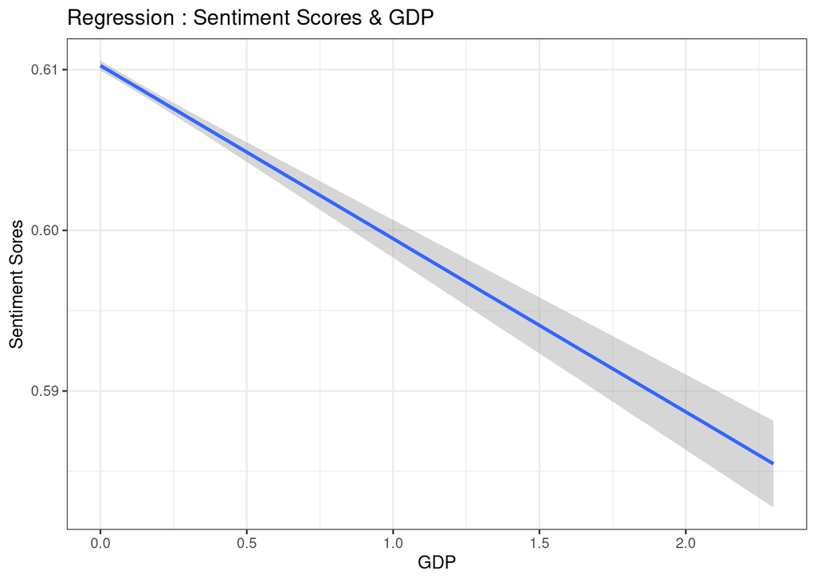

```r
plot1 <- plot1[[1]]

plot1 <- plot1 +
  labs(x = "GDP", y = "Sentiment Sores")+
  ggtitle("Regression : Sentiment Scores & GDP") +
  theme_bw()

plot1
```

```r
internet_users <- read.csv("internet_users.csv")

internet_users <- internet_users[c(2,3)]

internet_users<-internet_users %>% filter(!is.na(internet_users$X.1))

internet_users<-internet_users %>%  filter(!row_number() %in% c(1, 2, 3, 4))

names(internet_users)[names(internet_users) == "X.1"] <- "region"
names(internet_users)[names(internet_users) == "X.2"] <- "users"

df<-left_join(internet_users,data_total, by="region")

df<-df %>% filter(!is.na(df$SCORE))

df$users <- as.numeric(as.character(df$users))
```

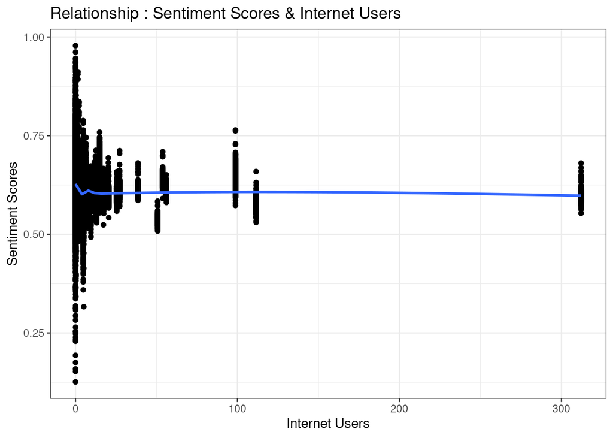

```r
ggplot(data = df, aes(x = users , y = SCORE))+
  geom_point() +
  geom_smooth()+
  ggtitle("Relationship : Sentiment Scores & Internet Users")+
  xlab("Internet Users")+
  ylab("Sentiment Scores")+
  theme_bw()
```

```r
dv2 <- brm(formula = SCORE~gdp+users, data=df, family=gaussian ,refresh=0)
```

[output not shown]

```r
draws_fit <- as_draws_df(dv2)
posterior::summarize_draws(draws_fit)
```

```
## # A tibble: 6 × 10
##   variable        mean   median       sd     mad       q5      q95  rhat ess_b…¹
##   <chr>          <dbl>    <dbl>    <dbl>   <dbl>    <dbl>    <dbl> <dbl>   <dbl>
## 1 b_Intercept  6.08e-1  6.08e-1  1.39e-4 1.36e-4  6.08e-1  6.09e-1  1.00   1452.
## 2 b_gdp       -1.55e-2 -1.55e-2  8.72e-4 8.64e-4 -1.69e-2 -1.40e-2  1.00   1196.
## 3 b_users      6.12e-5  6.12e-5  6.91e-6 6.89e-6  4.95e-5  7.26e-5  1.00   1686.
## 4 sigma        3.89e-2  3.89e-2  9.36e-5 9.52e-5  3.88e-2  3.91e-2  1.00   1772.
## 5 lprior      -3.14e+0 -3.14e+0  8.11e-7 8.16e-7 -3.14e+0 -3.14e+0  1.00   1746.
## 6 lp__         1.50e+5  1.50e+5  1.39e+0 1.19e+0  1.50e+5  1.50e+5  1.00   1267.
## # … with 1 more variable: ess_tail <dbl>, and abbreviated variable name
## #   ¹ess_bulk
```

```r
summary(dv2)
```

```
##  Family: gaussian
##   Links: mu = identity; sigma = identity
## Formula: SCORE ~ gdp + users
##    Data: df (Number of observations: 82305)
##   Draws: 4 chains, each with iter = 2000; warmup = 1000; thin = 1;
##          total post-warmup draws = 4000
##
## Population-Level Effects:
##           Estimate Est.Error l-95% CI u-95% CI Rhat Bulk_ESS Tail_ESS
## Intercept     0.61      0.00     0.61     0.61 1.00     1452     1630
## gdp          -0.02      0.00    -0.02    -0.01 1.00     1196     1071
## users         0.00      0.00     0.00     0.00 1.00     1686     2058
##
## Family Specific Parameters:
##       Estimate Est.Error l-95% CI u-95% CI Rhat Bulk_ESS Tail_ESS
## sigma     0.04      0.00     0.04     0.04 1.00     1772     1669
##
## Draws were sampled using sampling(NUTS). For each parameter, Bulk_ESS
## and Tail_ESS are effective sample size measures, and Rhat is the potential
## scale reduction factor on split chains (at convergence, Rhat = 1).
```

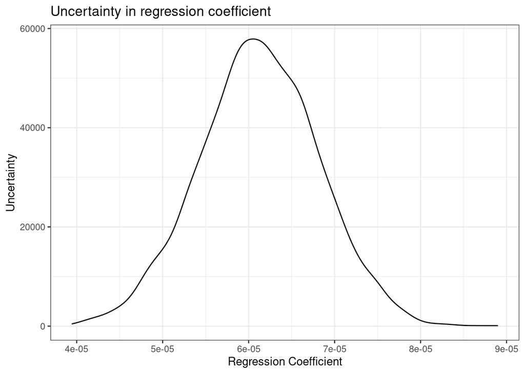

```r
attach(df)
uncertainty_coef<-as_draws_df(dv2, variable = "b_users")
ggplot(uncertainty_coef, aes(x=b_users))+
  geom_density()+
  labs(title= "Uncertainty in regression coefficient",x="Regression Coefficient",y="Uncertainty")+
  theme_bw()
```

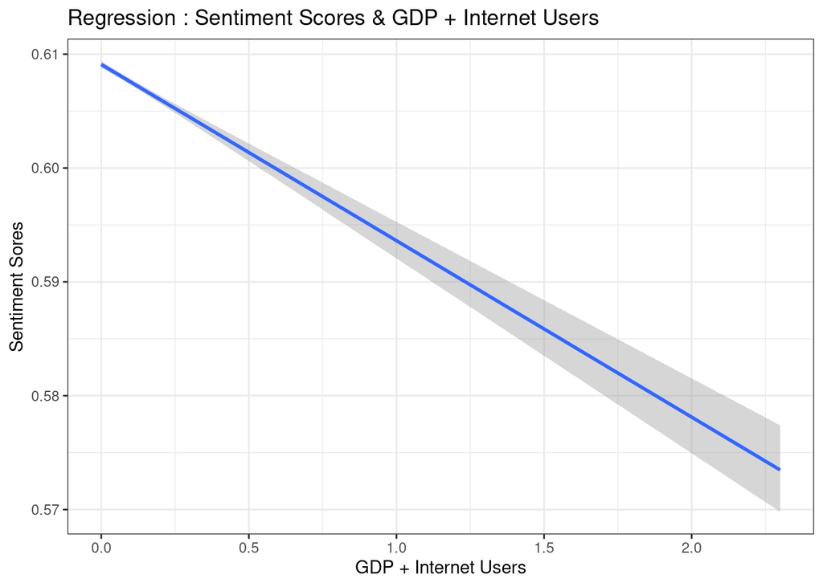

```r
plot2 <- plot2[[1]]

plot2 <- plot2 +
  labs(x = "GDP + Internet Users", y = "Sentiment Sores")+
  ggtitle("Regression : Sentiment Scores & GDP + Internet Users") +
  theme_bw()

plot2
```

```r
average_hours <- read.csv("average_hours.csv")

average_hours <- average_hours[c(1,3,4,76,77)]
average_hours<-average_hours %>%  filter(!row_number() %in% c(1, 2, 3))
average_hours <- dplyr::filter(average_hours, X.2 %in% c("Average Hours Worked"))
average_hours <- average_hours[c(2,4,5)]
names(average_hours)[names(average_hours) == "X.1"] <- "region"
names(average_hours)[names(average_hours) == "X.74"] <- "averageHours"
names(average_hours)[names(average_hours) == "X.75"] <- "averageHours"
#view(average_hours)

avg20 <- average_hours[c(1,2)]
avg21 <- average_hours[c(1,3)]

avg20['Year'] = '20'
avg21['Year'] = '21'
```

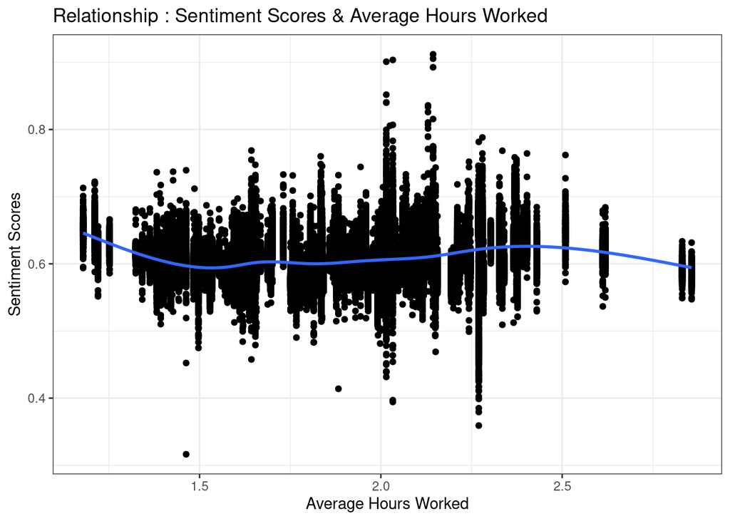

```r
avg_20 <- dplyr::filter(df, Year %in% c("20"))
avg_21 <- dplyr::filter(df, Year %in% c("21"))

avg_20 <- left_join(avg_20, avg20, by=c("region","Year"))
avg_21 <- left_join(avg_21, avg21, by=c("region","Year"))

data_total <- rbind(avg_20,avg_21)

data_total<- data_total %>% filter(!is.na(data_total$averageHours))

data_total$averageHours <- as.numeric(gsub(",","",data_total$averageHours))

data_total$averageHours <- data_total$averageHours/1000

ggplot(data = data_total, aes(x = averageHours , y = SCORE))+
  geom_point() +
  geom_smooth()+
  ggtitle("Relationship : Sentiment Scores & Average Hours Worked")+
  xlab("Average Hours Worked")+
  ylab("Sentiment Scores")+
  theme_bw()
```

```r
dv3 <- brm(formula = SCORE~gdp + users + averageHours, data=data_total, family=gaussian ,refresh=0)
```

[output not shown]

```r
draws_fit <- as_draws_df(dv3)
posterior::summarize_draws(draws_fit)
```

```
## # A tibble: 7 × 10
##   variable         mean   median      sd     mad       q5      q95  rhat ess_b…¹
##   <chr>           <dbl>    <dbl>   <dbl>   <dbl>    <dbl>    <dbl> <dbl>   <dbl>
## 1 b_Intercept   5.83e-1  5.83e-1 6.95e-4 6.65e-4  5.82e-1  5.85e-1  1.00   1292.
## 2 b_gdp        -1.04e-2 -1.04e-2 7.27e-4 7.17e-4 -1.16e-2 -9.22e-3  1.00   3447.
## 3 b_users       2.98e-5  2.98e-5 5.76e-6 5.75e-6  2.03e-5  3.93e-5  1.00   3598.
## 4 b_averageHo…  1.26e-2  1.26e-2 3.70e-4 3.59e-4  1.20e-2  1.32e-2  1.00   1316.
## 5 sigma         3.16e-2  3.16e-2 8.51e-5 8.49e-5  3.15e-2  3.18e-2  1.00   1515.
## 6 lprior       -3.14e+0 -3.14e+0 5.95e-7 5.79e-7 -3.14e+0 -3.14e+0  1.00   1533.
## 7 lp__          1.39e+5  1.39e+5 1.56e+0 1.44e+0  1.39e+5  1.39e+5  1.00   1467.
## # … with 1 more variable: ess_tail <dbl>, and abbreviated variable name
## #   ¹ess_bulk
```

```r
summary(dv3)
```

```
##  Family: gaussian
##   Links: mu = identity; sigma = identity
## Formula: SCORE ~ gdp + users + averageHours
##    Data: data_total (Number of observations: 68525)
##   Draws: 4 chains, each with iter = 2000; warmup = 1000; thin = 1;
##          total post-warmup draws = 4000
##
## Population-Level Effects:
##              Estimate Est.Error l-95% CI u-95% CI Rhat Bulk_ESS Tail_ESS
## Intercept        0.58      0.00     0.58     0.58 1.00     1292     1474
## gdp             -0.01      0.00    -0.01    -0.01 1.00     3447     2773
## users            0.00      0.00     0.00     0.00 1.00     3598     3272
## averageHours     0.01      0.00     0.01     0.01 1.00     1316     1403
##
## Family Specific Parameters:
##       Estimate Est.Error l-95% CI u-95% CI Rhat Bulk_ESS Tail_ESS
## sigma     0.03      0.00     0.03     0.03 1.00     1515     1414
##
## Draws were sampled using sampling(NUTS). For each parameter, Bulk_ESS
## and Tail_ESS are effective sample size measures, and Rhat is the potential
## scale reduction factor on split chains (at convergence, Rhat = 1).
```

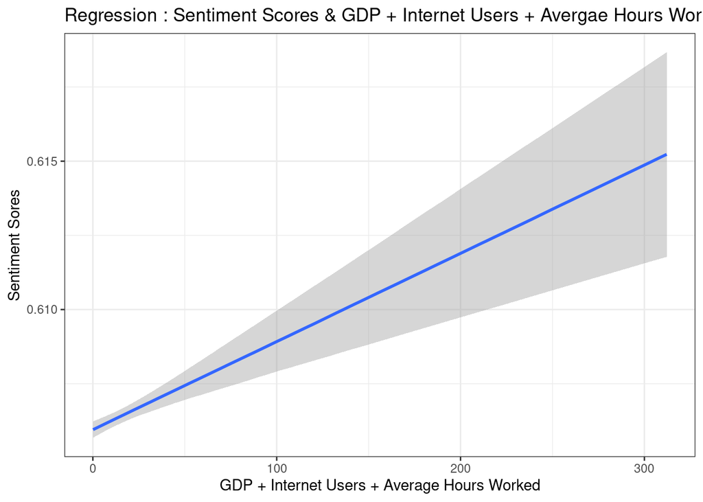

```r
plot3 <- plot3[[2]]

plot3 <- plot3 +
  labs(x = "GDP + Internet Users + Average Hours Worked", y = "Sentiment Sores")+
  ggtitle("Regression : Sentiment Scores & GDP + Internet Users + Avergae Hours Worked") +
  theme_bw()

plot3
```